# Druggability project

### Andreu Bofill, Inés Sentís, Mariona Torrens, Alejandro Varela

This project aims to provide a simple platform to detect among a set of ligands and a protein if their interaction result in a system with a free energy lower than -2 kcal/mol. This would reflect a good interaction between the ligand and the protein which is a very interesting property in a drug as, ideally, a low energy of interaction may correspond with a good drug candidate.

All the files obtained in this project are in the machine 1: student1@ace1.prib.upf.edu in the directory *Druggability_project*. There you will find a copy of the code we develop to carry on this project. The code is divided in a python script called SimulationModule.py and a jupyter notebook called AnalysisFINAL.ipynb. The first contains the following steps: parameterization, docking, building the system, equilibration of the system, production process and adaptative sampling. You must run independently the program for each ligand to obtain the necessary files. The jupyter notebook has the ligand binding analysis which in this case can do the analysis for all of the ligands at the same time.

```python
import os
from htmd import *
from htmd.molecule.util import maxDistance
from htmd.protocols.equilibration_v1 import Equilibration
from htmd.protocols.production_v1 import Production
from htmd.parameterize import Configuration, Parameterisation
from natsort import natsorted
import sys
import argparse
import random
```

As the SimulationModule.py must be executed from command line some arguments should be specified. There are two options: or pass to the program just the protein pdb file and the ligand mol2 file or pass the program all the files of the parameterization of the ligand. In case there is a missing file an exeption will show up. In the first case, you have to use –mol2 option to indicate the path to the ligand file and –prot plus the path to the protein pdb as it is showed below. Make sure that in the file `parameters.config` you indicate the correct molecular charge in the netcharge field.

For example:

```python
$python3 SimulationModule.py --prot parameters_files/trypsin.pdb --mol2 parameters_files/ethanol/ethanol.mol2
```

However, if you already have the topology(rtf) and parameter’s (prm) files from the ligand you can pass them as arguments to the python program using the options –rtf and –prm plus –ligand and the path to the corresponding files as it is shown in the example below:

```python
$python3 SimulationModule.py --prot parameters_files/trypsin.pdb --ligand parameters_files/ethanol/ethanol.pdb
    --rtf parameters_files/ethanol/ethanol.rtf -prm parameters_files/ethanol/ethanol.prm
```

All the files to perfom any of the two options presented above can be found at *Druggability_project/parameters_files* regardless of the option chosen.

```python
parser = argparse.ArgumentParser(description="Druggability Project")
parser.add_argument('-l', '--ligand',
dest='ligand',
action='store',
default=None,
required=False,
help='Ligand path')
```

```python
parser.add_argument('-p', '--prot',
dest='prot',
action='store',
default=None,
required=True,
help='Protein path')
```

```python
parser.add_argument('-rtf', '--rtf',
dest='rtf',
action='store',
default=None,
required=False,
help='rtf path')
```

```python
parser.add_argument('-prm', '--prm',
dest='params',
action='store',
default=None,
required=False,
help='Params path')
```

```python
parser.add_argument('-c', '--config',
dest='config',
action='store',
default='./parameters.config',
required=False,
help='Parameters configuration file')
```

```python
parser.add_argument('-mol2', '--mol2',
dest='mol2',
action='store',
default=None,
required=False,
help='mol2 file to generate rtf and prm files')

args = parser.parse_args()
```

```python
def check_arguments():
    if not args.prot:
        sys.stderr.write("Error: You forget to put the protein file path\n")
        exit(1)
    if args.ligand:
        if args.params and args.rtf:
            if args.mol2:
                sys.stderr.write("Error: You Introduce both options: mol2 and pdb,rtf,prm files.\
                                 Choose only one option\n")
                exit(1)
            ligand_path = args.ligand
            rtf_path = args.rtf
            params_path = args.params
        else:
            sys.stderr.write("Error: You introduce a ligand pdb file, but rtf and prm files are missing.\
            Introduce them with -rtf and -prm input options \n")
    if not args.ligand or not args.params or not args.rtf:
        if not args.mol2:
            sys.stderr.write("You need to introduce one ligand input options: \
            a mol2 file, or  pdb,rtf and prm files.\n")
            exit(1)
        if args.mol2:
            (ligand_path,rtf_path,params_path)=parameter(args.mol2, netcharge)
    return(ligand_path,rtf_path,params_path)
```

```python
def parse_config (config_file):
    op_config = open(config_file, "r")
    for line in op_config:
        if line.startswith("nbuilds"):
            nbuilds = line.split("\t")[1].strip()
        if line.startswith("minsim"):
            minsim = line.split("\t")[1].strip()
        if line.startswith("maxsim"):
            maxsim = line.split("\t")[1].strip()
        if line.startswith("run_time"):
            run_time = line.split("\t")[1].strip()
        if line.startswith("numbep"):
            numbep = line.split("\t")[1].strip()
        if line.startswith("dimtica"):
            dimtica = line.split("\t")[1].strip()
        if line.startswith("sleeping"):
            sleeping = line.split("\t")[1].strip()
        if line.startswith("netcharge"):
            netcharge = line.split("\t")[1].strip()
            print(netcharge)
    return(nbuilds, run_time, minsim, maxsim, numbep, dimtica, sleeping, netcharge)
```

The function *parameter* would be executed just in case the parametrization files of the ligand were not specified at the beginning. This process is really computationally demanding and depends on the number of atoms of the molecule being parameterized. Charge of the ligand must also be specified.

```python
def parameter(mol2, netcharge):
    molec = Molecule(mol2)
    config = Configuration()
    config.FileName = mol2
    molec_name = str(mol2)
    molec_name = molec_name.split(".")[0]
    config.JobName = molec_name.split("/")[-1]+str(random.randint(1,1000))
    config.NetCharge = netcharge
    param = Parameterisation(config=config)
    paramfiles = param.getParameters()
    shutil.copyfile(paramfiles['RTF'], molec_name+".rtf")
    shutil.copyfile(paramfiles['PRM'], molec_name+".prm")
    shutil.copyfile(paramfiles['PDB'], molec_name+".pdb")
    ligand_path = molec_name+".pdb"
    params_path = molec_name+".prm"
    rtf_path = molec_name+".rtf"
    return(ligand_path, params_path, rtf_path)
```

Once we have the ligand parameterized, this platform initializes the system by doing a docking between the ligand and the protein using the *dock* function of HTMD. The top 5 poses are used to build the systems, each pose is built independently. The point of starting with docked position is that it ensures a good starting point to run a simulation and saves time and computer resources.

```python
def dockinit(protein_path, ligand_path):
    prot = Molecule(protein_path)
    prot.filter('protein or water or resname CA')
    prot.set('segid', 'P', sel='protein and noh')
    prot.set('segid', 'W', sel='water')
    prot.set('segid', 'CA', sel='resname CA')
    D = maxDistance(prot, 'all')
    D = D + 15
    prot.center()
    lig = Molecule(ligand_path)
    poses, scores = dock(prot, lig)
    return (prot, poses, D)
```

Each of the five different poses are solvated and a salt concentration of 0.15 is added as we have seen in the HTMD documentation.

```python
def building(prot,poses,D,path_ligand_rtf,path_ligand_prm,nbuilds=4):
    moltbuilt=[]
    for i, p in enumerate(poses):
        ligand = p
        ligand.set('segid','L')
        ligand.set('resname','MOL')
        mol = Molecule(name='combo')
        mol.append(prot)
        mol.append(ligand)

        smol = solvate(mol, minmax=[[-D, -D, -D], [D, D, D]])
        topos  = ['top/top_all22star_prot.rtf', 'top/top_water_ions.rtf',path_ligand_rtf]
        #'parameters_files/ethanol/ethanol.rtf'
        params = ['par/par_all22star_prot.prm', 'par/par_water_ions.prm', path_ligand_prm]
        #'parameters_files/ethanol/ethanol.prm'

        moltbuilt.append(charmm.build(smol, topo=topos, param=params,
                outdir='./docked/build/{}/'.format(i+1), saltconc=0.15))
        if i==nbuilds:
            break
```

After this, an equilibration protocol is performed over each system. This allows us to stablish a temperature of 298 Kelvin on each system using 1000 time steps.

```python
def Equilibrate():
    md = Equilibration()
    md.numsteps = 1000
    md.temperature = 298
    builds=natsorted(glob('docked/build/*/'))
    for i,b in enumerate(builds):
        md.write(b,'docked/equil/{}/'.format(i+1))
    mdx = AcemdLocal()
    mdx.submit(glob('./docked/equil/*/'))
    mdx.wait()
```

The already equilibrated systems enter the production step where trajectories for each system are created using the Newton equations of motion. In this step, a ‘generators’ directory is created. It will contain 5 folders (as we have stablished by default) with a one simulation each. The generators are only used in the first epoch.

```python
def Produce(run_time=50):
    equils=natsorted(glob('docked/equil/*/'))
    for i,b in enumerate(equils):
        md= Production()
        md.acemd.bincoordinates = 'output.coor'
        md.acemd.extendedsystem  = 'output.xsc'
        md.acemd.binvelocities=None
        md.acemd.binindex=None
        md.acemd.run=str(run_time)+'ns'
        md.temperature = 300
        equils=natsorted(glob('docked/equil/*/'))
        md.write('./docked/equil/{}/'.format(i+1), 'docked/generators/{}/'.format(i+1))

    mdx = AcemdLocal()
    mdx.submit(glob('./docked/generators/*/'))
    mdx.wait()
```

Finally, we run adaptive to generate the trajectories which will eventually be used for the ligand binding analysis. A folder called *filtered* will be created in the working directory which will contain the filtered trajectories (without water). The point of doing adaptative is to accelerate the simulation proccess by selecting those results that represent an advanced position to avoid repetition from the beginning and explore more space.

```python
def adaptive(minsim=6,maxsim=8,numbep=12,dimtica=3,sleeping=14400):
    md = AdaptiveRun()
    md.nmin=minsim
    md.nmax=maxsim
    md.nepochs = numbep
    md.app = AcemdLocal()
    md.generatorspath='./docked/generators/'
    md.datapath='./docked/generators/'
    md.inputpath='./docked/generators/'
    md.dryrun = False
    md.metricsel1 = 'name CA'
    md.metricsel2 = 'resname MOL and noh'
    md.metrictype = 'contacts'
    md.ticadim = dimtica
    md.updateperiod = sleeping
    md.run()
```

To obtain enough trajectories, you should let this run for several days, and then stop it. For this project we have spent an average of 3 days to obtan the trajectories that are provided at the machine.

## Analysis of the results:

Fisrt of all, we obtain a simulation list from our trajectories, created at the previous stage of the program.

```python
sims = simlist(glob('./filtered/*/'), './filtered/filtered.pdb')
```

To build a Markov states model we need to project the atom coordinates onto a lower dimensional space, which can be used for clustering the conformations into a set of states. To do this, we use a binary contact map between the carbon alpha atoms of the protein and the ligand.

```python
metr = Metric(sims)
metr.projection(MetricDistance('protein and name CA', 'resname MOL and noh', metric='contacts'))
data = metr.project()
```

We define which is the frame-step, in nanoseconds.

```python
data.fstep = 0.1
```

We visualize now the length of the trajectories to see if they are equal. The trajectories that are not equal are eliminated because, probably, they are corrupted.

```python
data.plotTrajSizes()
data.dropTraj()
```

TICA is performed to achive greater differentiation of metastable minima.

```python
tica = TICA(data, 10)
dataTica = tica.project(3)
```

We apply bootstrap. Then, we cluster the conformations: we produce 1000 clusters, and clusters containing less than 5 conformations will be merged into the next neighbour.

```python
dataBoot = dataTica.bootstrap(0.8)
dataBoot.cluster(MiniBatchKMeans(n_clusters=1000), mergesmall=5)
```

Once the clustering is done, it is time to construct the markov model. To do this, an ITS plot has to be observed to see at which lag-time do timescales start converging and, also, to see how many different timescales there are.

```python
model = Model(dataBoot)
model.plotTimescales()
```

According to the ITS plot, we choose the lag-time and the numer of macrostate. In this example, we set these values to 50 and 5, respectively.

```python
model.markovModel(50, 5)
```

Now we will visualize the states: we load the 5 macrostates and add a ligand representation.

```python
htmd.config(viewer='vmd')
model.viewStates(ligand='resname MOL and noh')
mols = model.getStates()
print(mols)
```

Each state is a set of binding poses (conformations) which were given by the Markov Model, which considered that they were kinetically different.

```python
model.viewStates(ligand='resname MOL and noh')
```

Now we want to obtain quantitative results about the kinetics between states. We use the Kinetics constructor, where we indicate the system temperature and ligand concentration.

```python
kin = Kinetics(mols[1], temperature=298, concentration=0.0037)

r = kin.getRates()
print(r.g0eq)
```

```python
kin.plotRates(rates=('g0eq'))
```

```python
kin.plotFluxPathways()
```

### Results

Here we present some of the results we have obtained. We only present the results from ethanol because it is the ligand with more trajectories and, therefore, yields better results. A part from that, due to a lack of time we don’t have the trajectories for the glutamate. However, it is still running in the second machine to see if we can analyze it in a few days.

Here is the plot of the length trajectories. The trajectories that were the shortest were removed.

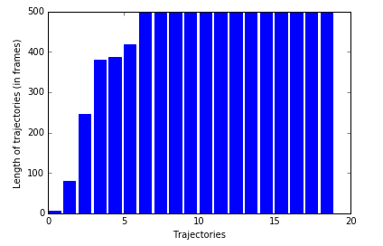

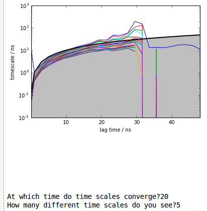

If we visualize the states at VMD we can confirm that docking was not the best approach.

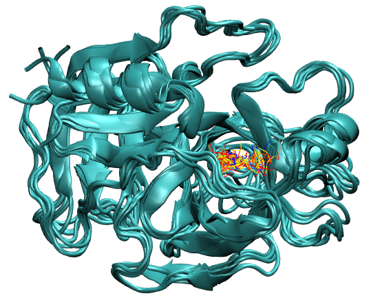

We calculated the kinetics between states as we can see in the diagram flux of the Markov Model:

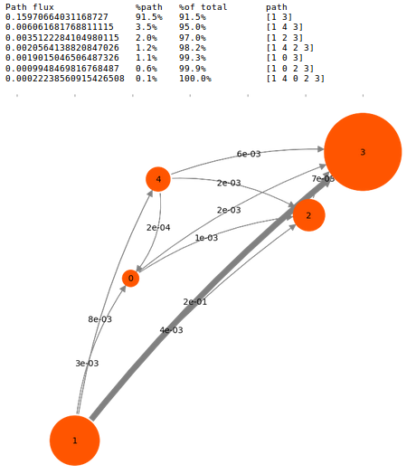

### Conclusions

In this project we have followed a “sticky poses” strategy, which means that we were looking for the strongest association/position of the ligand and the protein. In addition, with the docking that we have done at the beginning, we started the simulations already from a very metastable state, which has limited the ligand to the exploration of more space. If we hadn’t applied docking at the beginning, maybe we would have obtained better results.

As we have explained above, we have let the adaptative sampling process running during 2-3 days for each ligand with a resource of 4 GPUs per ligand. With this, we have obtained just a few trajectories. Our opinion is that with more time (and therefore more trajectories) our results would be more consistent. However, it could also be that the problem was not the running-time issue but the fact that we have done docking before building the system.